# Preprocessing - Feature scaling

## Why feature scaling

- feature scaling in machine learning is one of the most critical steps during the pre-processing
- scaling can make a difference between a weak machine learning model and a better one
- we don’t want the higher number (scaling) to dominate in a model
- the most common techniques of feature scaling are Normalization and Standardization

## When to do feature scaling

- essential for machine learning algorithms that calculate distances between data
- if not scale, the feature with a higher value range starts dominating when calculating distances
- in many algorithms, when we desire faster convergence, scaling is a MUST like in Neural Network
- rule of thumb we may follow here is an algorithm that computes distance or assumes normality, scale your features

## Algorithms where feature scaling matters

- K-nearest neighbors
- K-means
- SVM
- Principal Component Analysis(PCA)
- gradient descent

## Algorithms where feature scaling matters - example

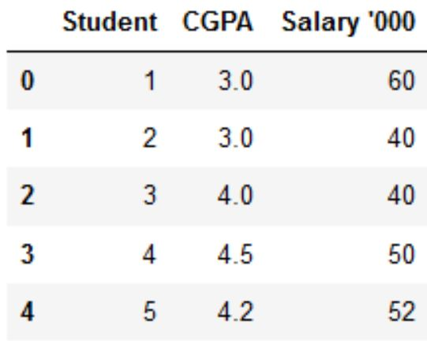

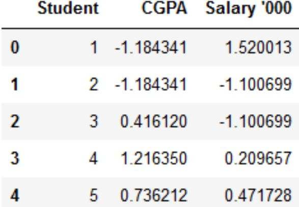

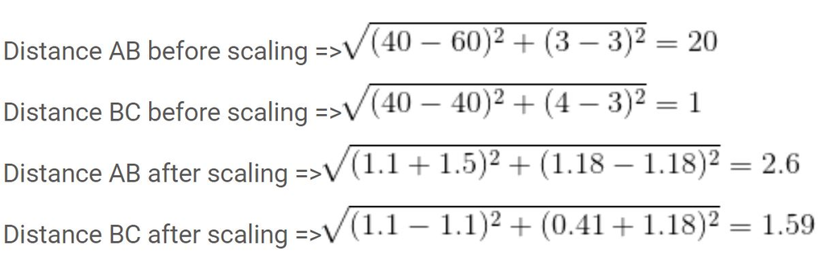

## Algorithms where feature scaling doesn’t matter

- these algorithms rely on rules
- all tree-based algorithms
- Linear Discriminant Analysis(LDA)
- Naive Bayes

## Normalization and standardization

- normalization is used when we want to bound our values between two numbers, typically, between [0,1] or [-1,1]
- standardization transforms the data to have zero mean and a variance of 1

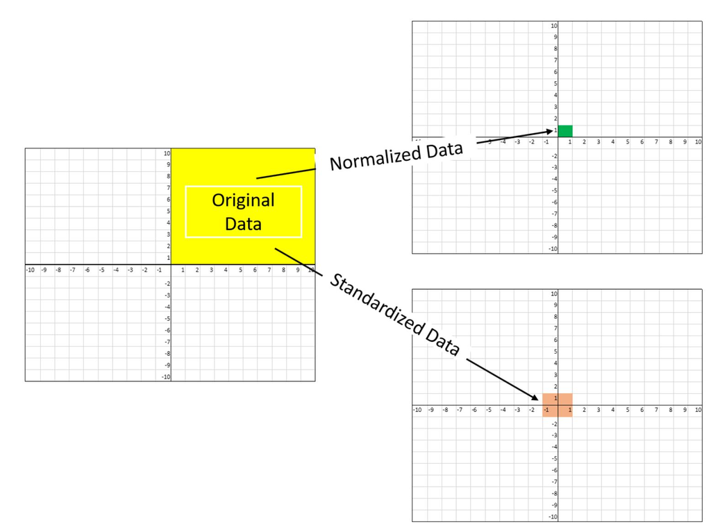

## To normalize or to standardize data

- normalize when data is not normaly distributed
- standardization when data is normaly distributed
- standardization doesn’t affect the outliers
- *normalization or standardization will depend on your problem and the machine learning algorithm you are using*

## How to perform feature scaling

- Min Max Scaler
- Standard Scaler
- Max Abs Scaler
- Robust Scaler
- …

## Min Max scaler

- m = (x -xmin) / (xmax -xmin)

## Lab

- create UDF for min max scaler in Python and R

## Solution

```
#Python
def min_max_normalization(values):
    minx=min(values)
    maxx=max(values)
    return [(x-minx)/(maxx-minx) for x in values]
#R
normalizeF<-function(x) {return((x-min(x))/(max(x)-min(x)))}
```

## Min Max scaler - Python

```python
import pandas as pd
import numpy as np
from sklearn.preprocessing import MinMaxScaler

iris = pd.read_csv('https://raw.githubusercontent.com/mwaskom/seaborn-data/master/iris.csv')

iris_numeric=iris.select_dtypes([np.number])
iris_numeric.head(3)
```

```
##    sepal_length  sepal_width  petal_length  petal_width
## 0           5.1          3.5           1.4          0.2
## 1           4.9          3.0           1.4          0.2
## 2           4.7          3.2           1.3          0.2
```

```python
iris_norm=pd.DataFrame(MinMaxScaler().fit_transform(iris_numeric), columns=iris_numeric.columns)
iris_norm.head(3)
```

```
##    sepal_length  sepal_width  petal_length  petal_width
## 0      0.222222     0.625000      0.067797     0.041667
## 1      0.166667     0.416667      0.067797     0.041667
## 2      0.111111     0.500000      0.050847     0.041667
```

## Min Max scaler - R

```r
library(heatmaply)

iris_norm<-normalize(iris)
head(iris_norm,3)
```

```
##   Sepal.Length Sepal.Width Petal.Length Petal.Width Species
## 1    0.2222222   0.6250000   0.06779661  0.04166667  setosa
## 2    0.1666667   0.4166667   0.06779661  0.04166667  setosa
## 3    0.1111111   0.5000000   0.05084746  0.04166667  setosa
```

## Standardization

- m=(X – μ )/ σ

## Lab

- create UDF for standardization in Python and R

## Solution

```
#Python
import statistics as s
def standardization(values):
    meanx=s.mean(values)
    stdx=s.stdev(values)
    return [(x-meanx)/stdx for x in values]
#R
standardizeF<-function(x) {return((x-mean(x))/sd(x))}
```

## Standard scaler - Python

```python
import pandas as pd
import numpy as np
from sklearn.preprocessing import StandardScaler

iris = pd.read_csv('https://raw.githubusercontent.com/mwaskom/seaborn-data/master/iris.csv')

iris_numeric=iris.select_dtypes([np.number])
iris_numeric.head(3)
```

```
##    sepal_length  sepal_width  petal_length  petal_width
## 0           5.1          3.5           1.4          0.2
## 1           4.9          3.0           1.4          0.2
## 2           4.7          3.2           1.3          0.2
```

```python
iris_stand=pd.DataFrame(StandardScaler().fit_transform(iris_numeric), columns=iris_numeric.columns)
iris_stand.head(3)
```

```
##    sepal_length  sepal_width  petal_length  petal_width
## 0     -0.900681     1.019004     -1.340227    -1.315444
## 1     -1.143017    -0.131979     -1.340227    -1.315444
## 2     -1.385353     0.328414     -1.397064    -1.315444
```

## Standard scaler - R

```r
iris_stand<-scale(iris[,1:4])
head(iris_stand,3)
```

```
##      Sepal.Length Sepal.Width Petal.Length Petal.Width
## [1,]   -0.8976739   1.0156020    -1.335752   -1.311052
## [2,]   -1.1392005  -0.1315388    -1.335752   -1.311052
## [3,]   -1.3807271   0.3273175    -1.392399   -1.311052
```

## Max Abs Scaler - Python

```python
import pandas as pd
import numpy as np
from sklearn.preprocessing import MaxAbsScaler

iris = pd.read_csv('https://raw.githubusercontent.com/mwaskom/seaborn-data/master/iris.csv')

iris_numeric=iris.select_dtypes([np.number])
iris_numeric.head(3)
```

```
##    sepal_length  sepal_width  petal_length  petal_width
## 0           5.1          3.5           1.4          0.2
## 1           4.9          3.0           1.4          0.2
## 2           4.7          3.2           1.3          0.2
```

```python
iris_maxabs=pd.DataFrame(MaxAbsScaler().fit_transform(iris_numeric), columns=iris_numeric.columns)
iris_maxabs.head(3)
```

```
##    sepal_length  sepal_width  petal_length  petal_width
## 0      0.645570     0.795455      0.202899         0.08
## 1      0.620253     0.681818      0.202899         0.08
## 2      0.594937     0.727273      0.188406         0.08
```

## Max Abs Scaler - R

```r
library(purrr)
MaxAbs<-function(x) {return (x/max(abs(x)))}

iris_maxabs<-map_df(iris[,1:4],MaxAbs)
head(iris_maxabs,3)
```

```
## # A tibble: 3 x 4
##   Sepal.Length Sepal.Width Petal.Length Petal.Width
##          <dbl>       <dbl>        <dbl>       <dbl>
## 1        0.646       0.795        0.203        0.08
## 2        0.620       0.682        0.203        0.08
## 3        0.595       0.727        0.188        0.08
```

## Lab

- take the mtcars dataset (only mpg and hp columns)

```
for Python:
data = pd.read_csv('https://tinyurl.com/yayk2qy5')
data.rename(columns={'Unnamed: 0':'brand'}, inplace=True)
```

- explore data distributions (scatter plot, histogram)
- decide for a certain scaling technique
- again explore data distribution